# 净胜球形态、完整赛果组合与动态购票

本研究直接枚举七场让球胜平负的全部2187种组合，不设3332222等结果结构。采用FM-1.7.1选定来源的完整比分分布，不使用90%尾部压缩；不是更改正式FM171。为隔离购票与概率的作用，固定已有七轮各自原8组比赛，每组125注、2元/注、每轮2000元。所有赛果均可进入候选；8组只是本轮控制变量，不是最终策略约束。本轮不同时扩大选场池或优化组数。

如果模型正确且各注同价，单组概率前125注最大化单组命中。动态窗口若仅最大化单组质量也应从第1名开始；本研究用其他组尚未覆盖的概率定义动态目标。比较FIXED（30–154）、TOP（1–125）、DYNAMIC_WINDOW（贪心选下一组及连续125注）、DYNAMIC_SET（贪心选下一组及任意125注）。后两者最大化当步新增联合覆盖，不宣称全局最优或收益最优；同一比赛在全部组中共享结果，不把8组视为独立。重复票保留成本和重复中奖的回款，但不增加联合覆盖。

## 数据与时序

训练集来自26098、26101、26102三期322场成功同赛事原生/合格市场预测，使用SOURCE_FULL而非尾部版本。标签时钟使用已记录的整期观察时间，分别为10月7日、7日、9日；预测来源时间仍含历史代理，后来的FM171重建不能冒称当时真实可用。故所有结果均为历史诊断。七轮目标为10月15–17日的26104/26105；每轮明确截止，shared temporal_learning只准入截止前、非目标期历史。训练特征仅熵entropy与让平净胜球±1档合计local_mass；不因目标赛果挑特征或幅度。

三种概率：RAW为完整网格投影；GLOBAL为三类原始logit作为offset、仅截距的二项残差校准；SHAPE在相同offset上增加entropy/local_mass。三类各自拟合后归一化，以GLOBAL隔离整体校准贡献。固定等权、ESS≥100、每类至少15、epsilon=1e−8；不搜索超参数。默认全部322场历史，不加入目标期已结束比赛。每个目标截止独立构建共享上下文、拟合和收据，无跨截止模型缓存。

这七轮赛果已被讨论，不能当盲测，也不能按其结果挑最佳生产方案；但规则不使用其标签拟合/选择，训练和评分跨期分离。各轮重复比赛，主概率指标仅保留每场首次截止，另存完整fixture/cutoff评分。回款缺SP则NA，不记零、不据此推断全期ROI。

## 概率有没有变准

```r
round_lookup <- map_dfr(x$rounds,~tibble(index=.x$index,batch=.x$dataset,sheet=.x$sheet,
 forecasts=nrow(.x$features),cutoff_utc=format(.x$cutoff$cutoff_utc,tz='UTC',usetz=TRUE)))
knitr::kable(round_lookup,caption='本次七轮映射：各轮保留原8组，截止时间为UTC')
```

本次七轮映射：各轮保留原8组，截止时间为UTC

| index | batch | sheet | forecasts | cutoff_utc |
| --- | --- | --- | --- | --- |
| 4 | fm17-upcoming-20261015 | 1 | 9 | 2026-10-14 14:25:51 UTC |
| 5 | fm17-upcoming-20261015 | 2 | 10 | 2026-10-14 14:25:51 UTC |
| 6 | fm17-upcoming-20261016 | 1 | 8 | 2026-10-15 16:41:39 UTC |
| 7 | fm17-upcoming-20261017 | 1 | 14 | 2026-10-16 15:48:46 UTC |
| 8 | fm17-upcoming-20261017 | 2 | 14 | 2026-10-16 15:48:46 UTC |
| 9 | fm17-upcoming-20261017 | 3 | 13 | 2026-10-16 15:48:46 UTC |
| 10 | fm17-upcoming-20261017 | 4 | 11 | 2026-10-16 15:48:46 UTC |

```r
write_csv(round_lookup,file.path(out,'round-lookup.csv'))
```

本次探索的主要观察：RAW固定窗口确认命中3轮、13组；动态连续窗口确认命中5轮、10组；动态任意125注确认命中6轮、6组，另1轮有1组待定。三者每轮均模拟投入2000元。动态选择扩大了轮次覆盖，同时改变了重复多中的分布，不能只用一种命中指标评价。

在78场已确认赛果中，RAW的Top1/Top2为44.87%/74.36%，SHAPE为39.74%/70.51%；SHAPE的Brier和log loss也更差。这支持继续研究完整组合及组间互补选择，不支持据此将本次两特征形态校准升级为正式概率。三期训练、两期目标的跨期分离仍受历史重建、目标已知和小样本限制，不是盲测或前瞻效果证明。

Brier为三类别平方误差之和，log loss为实际类别负对数概率；两者越低越好。Top2是让球胜平负前两类覆盖，不是净胜球前两档。

```r
knitr::kable(metrics,digits=6)
```

| model | n | hits1 | hits2 | top1 | top2 | brier | logloss |
| --- | --- | --- | --- | --- | --- | --- | --- |
| GLOBAL | 78 | 36 | 60 | 0.461538 | 0.769231 | 0.639253 | 1.058133 |
| RAW | 78 | 35 | 58 | 0.448718 | 0.743590 | 0.634882 | 1.052989 |
| SHAPE | 78 | 31 | 55 | 0.397436 | 0.705128 | 0.668032 | 1.098830 |

```r
knitr::kable(issues,digits=6,caption='逐期，重复比赛只保留首次截止')
```

逐期，重复比赛只保留首次截止

| issue_id | model | n | hits1 | hits2 | brier | logloss |
| --- | --- | --- | --- | --- | --- | --- |
| 26104 | GLOBAL | 27 | 12 | 21 | 0.646247 | 1.065029 |
| 26104 | RAW | 27 | 10 | 21 | 0.634472 | 1.044822 |
| 26104 | SHAPE | 27 | 11 | 19 | 0.671340 | 1.105704 |
| 26105 | GLOBAL | 51 | 24 | 39 | 0.635551 | 1.054482 |
| 26105 | RAW | 51 | 25 | 37 | 0.635100 | 1.057312 |
| 26105 | SHAPE | 51 | 20 | 36 | 0.666280 | 1.095190 |

```r
knitr::kable(missing_labels |> distinct(index,fixture_id,reason),caption='缺失标签逐项披露，不记成预测失败')
```

缺失标签逐项披露，不记成预测失败

| index | fixture_id | reason |
| --- | --- | --- |
| 8 | 26105:112 | Absent from immutable settlement snapshot |

原结算快照缺26105:112（布尔诺阿特斯–波希米亚1905）的标签。该场保留全部预测及选票；概率评分仅在所有模型共同的已知标签场次上计算。相关票若被其他已知腿否决，可确认未中；尚存中奖可能的票/组保留pending。any_hit在已确认命中时为TRUE、已确认全未中时为FALSE、其余为NA；汇总列出确认命中与待定上界，不把NA当零。没有用当前SP或猜测比分补标签。

agent-reach/Jina Reader核验的[球探现场页](https://live.titan007.com/detail/3039908.htm)显示该场“推迟”；原始读取内容保存在agent-reach持久目录，来源URL、采集时间与SHA见postponement-evidence.json。该状态仅解释缺标签，不进入拟合或补造结算。

形态校准只检验两个连续特征。GLOBAL只有截距，不能排除形态特征只是帮助表达原三分类概率的非线性校准；这不是“发现独立于原概率的新信息”的充分证据。训练混合原生/市场路由，目标组以市场路由为主，也存在来源及赛事构成变化。本轮不根据目标表现改变特征、加入交互项或另挑模型。

## 回到净胜球分布

按RAW与SHAPE三分类概率的总变差距离降序选择前三场，并以fixture_id打破并列；先限于已知标签场次的每场首次截止，再取例，不按命中择例。图只展示原完整净胜球分布，不声称GLM重新估计了比分；虚线为让平档，横轴窗口为让平±5球，窗口外质量另外列出且不重新归一化。

```r
projections <- map_dfr(x$rounds,~map_dfr(names(.x$outputs),function(model)
 .x$outputs[[model]]$decision$probabilities |> mutate(index=.x$index,model=model)))
stopifnot(nrow(projections)==711L)
write_csv(projections,file.path(out,'probabilities.csv'))
forecast_context <- map_dfr(x$rounds,~.x$features |>
 select(fixture_id,handicap,entropy,local_mass,mean_margin) |>
 mutate(index=.x$index,issue_id=.x$cutoff$issue_id,cutoff_utc=.x$cutoff$cutoff_utc))
stopifnot(nrow(forecast_context)==79L,!anyDuplicated(forecast_context[c('index','fixture_id')]),
 !anyNA(forecast_context))
write_csv(forecast_context,file.path(out,'forecast-context.csv'))
raw_purchases <- map_dfr(x$rounds,~.x$outputs$RAW$selection$purchases |>
 mutate(index=.x$index,issue_id=.x$cutoff$issue_id,
  cutoff_utc=format(.x$cutoff$cutoff_utc,tz='UTC',usetz=TRUE)))
stopifnot(nrow(raw_purchases)==28000L,
 all((raw_purchases |> count(index,policy,group_id))$n==125L))
write_csv(raw_purchases,file.path(out,'raw-ticket-selections.csv'))
first_context <- scores |> filter(model=='RAW') |> select(fixture_id,index)
changes <- projections |> inner_join(first_context,by=c('fixture_id','index'),relationship='many-to-one') |>
 filter(model%in%c('RAW','SHAPE')) |> pivot_wider(names_from=model,values_from=probability) |>
 group_by(index,fixture_id) |> summarise(total_variation=.5*sum(abs(RAW-SHAPE)),.groups='drop')
examples <- changes |> arrange(desc(total_variation),fixture_id) |> slice_head(n=3)
parent <- readRDS(file.path(root,manifest$sources$parent))
example_margins <- list();example_windows <- list()
for(j in seq_len(nrow(examples))) {
 i <- examples$index[j];id <- examples$fixture_id[j]
 f <- x$rounds[[as.character(i)]]$features |> filter(fixture_id==id)
 g <- parent$grids[[paste(i,id,sep='|')]]$grid |> as_tibble()
 m <- g |> mutate(margin=home_goals-away_goals) |> group_by(margin) |>
  summarise(probability=sum(probability),.groups='drop') |> mutate(fixture_id=id,draw_margin=-f$handicap)
 stopifnot(nrow(f)==1L,abs(sum(m$probability)-1)<1e-9)
 example_windows[[id]] <- tibble(fixture_id=id,outside_display_mass=
  sum(m$probability[abs(m$margin-m$draw_margin)>5]))
 example_margins[[id]] <- m |> filter(abs(margin-draw_margin)<=5)
}
knitr::kable(examples |> left_join(bind_rows(example_windows),by='fixture_id',relationship='one-to-one'),digits=5)
```

| index | fixture_id | total_variation | outside_display_mass |
| --- | --- | --- | --- |
| 5 | 26104:41 | 0.20680 | 0.00890 |
| 4 | 26104:44 | 0.18706 | 0.00981 |
| 10 | 26105:51 | 0.18426 | 0.00578 |

```r
knitr::kable(scores |> semi_join(examples,by=c('fixture_id','index')) |>
 select(fixture_id,model,actual_outcome,predicted_outcome,actual_rank,actual_probability,brier),digits=5)
```

| fixture_id | model | actual_outcome | predicted_outcome | actual_rank | actual_probability | brier |
| --- | --- | --- | --- | --- | --- | --- |
| 26104:44 | RAW | L | L | 1 | 0.50158 | 0.37481 |
| 26104:44 | GLOBAL | L | L | 1 | 0.43655 | 0.47642 |
| 26104:44 | SHAPE | L | W | 2 | 0.31452 | 0.71394 |
| 26104:41 | RAW | W | L | 2 | 0.37871 | 0.60473 |
| 26104:41 | GLOBAL | W | W | 1 | 0.39044 | 0.56360 |
| 26104:41 | SHAPE | W | W | 1 | 0.54496 | 0.31080 |
| 26105:51 | RAW | D | W | 3 | 0.20731 | 0.94268 |
| 26105:51 | GLOBAL | D | W | 3 | 0.25964 | 0.82624 |
| 26105:51 | SHAPE | D | W | 2 | 0.23115 | 0.95201 |

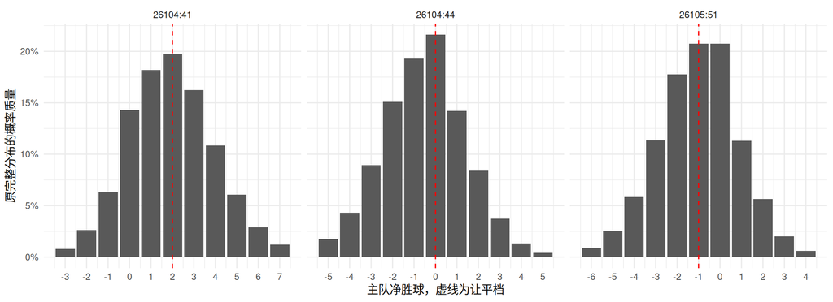

```r
bind_rows(example_margins) |> ggplot(aes(margin,probability))+
 geom_col()+geom_vline(aes(xintercept=draw_margin),linetype=2,colour='red')+
 facet_wrap(~fixture_id,scales='free_x')+scale_x_continuous(breaks=scales::breaks_width(1))+
 scale_y_continuous(labels=scales::percent)+
 labs(x='主队净胜球，虚线为让平档',y='原完整分布的概率质量')+theme_minimal()
```

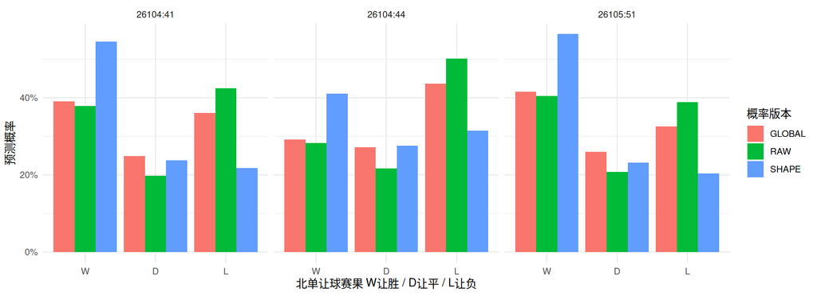

```r
projections |> semi_join(examples,by=c('fixture_id','index')) |>
 ggplot(aes(factor(outcome,levels=c('W','D','L')),probability,fill=model))+
 geom_col(position='dodge')+facet_wrap(~fixture_id)+scale_y_continuous(labels=scales::percent)+
 labs(x='北单让球赛果 W让胜 / D让平 / L让负',y='预测概率',fill='概率版本')+theme_minimal()
```

## 固定预算购票

model_any_hit是模型认为整轮至少中一注的概率，不是实测命中率；概率版本不同，其自身估计的覆盖不可直接当成真实收益比较。

```r
knitr::kable(summary,digits=5)
```

| model | policy | rounds | hit_rounds | pending_rounds | hit_rounds_upper | hit_groups | pending_groups | cost_cny | model_any_hit | cash_complete_rounds |
| --- | --- | --- | --- | --- | --- | --- | --- | --- | --- | --- |
| GLOBAL | DYNAMIC_SET | 7 | 5 | 1 | 6 | 6 | 1 | 14000 | 0.63647 | 3 |
| GLOBAL | DYNAMIC_WINDOW | 7 | 3 | 1 | 4 | 3 | 2 | 14000 | 0.58686 | 4 |
| GLOBAL | FIXED | 7 | 2 | 1 | 3 | 7 | 2 | 14000 | 0.36732 | 5 |
| GLOBAL | TOP | 7 | 2 | 0 | 2 | 7 | 0 | 14000 | 0.34063 | 6 |
| RAW | DYNAMIC_SET | 7 | 6 | 1 | 7 | 6 | 1 | 14000 | 0.67508 | 3 |
| RAW | DYNAMIC_WINDOW | 7 | 5 | 0 | 5 | 10 | 0 | 14000 | 0.60866 | 5 |
| RAW | FIXED | 7 | 3 | 0 | 3 | 13 | 0 | 14000 | 0.40347 | 5 |
| RAW | TOP | 7 | 3 | 0 | 3 | 11 | 0 | 14000 | 0.37774 | 5 |
| SHAPE | DYNAMIC_SET | 7 | 5 | 1 | 6 | 5 | 1 | 14000 | 0.71768 | 3 |
| SHAPE | DYNAMIC_WINDOW | 7 | 3 | 1 | 4 | 5 | 2 | 14000 | 0.66459 | 4 |
| SHAPE | FIXED | 7 | 1 | 0 | 1 | 6 | 0 | 14000 | 0.43221 | 7 |
| SHAPE | TOP | 7 | 1 | 0 | 1 | 5 | 0 | 14000 | 0.41823 | 7 |

```r
knitr::kable(rounds |> select(index,model,policy,hit_groups,any_hit,model_any_hit,payout_cny),digits=5)
```

| index | model | policy | hit_groups | any_hit | model_any_hit | payout_cny |
| --- | --- | --- | --- | --- | --- | --- |
| 4 | RAW | FIXED | 4 | TRUE | 0.45573 | 2900.5225 |
| 4 | RAW | TOP | 3 | TRUE | 0.43725 | 1424.2616 |
| 4 | RAW | DYNAMIC_WINDOW | 3 | TRUE | 0.65007 | 2405.0361 |
| 4 | RAW | DYNAMIC_SET | 1 | TRUE | 0.72141 | 529.1015 |
| 4 | GLOBAL | FIXED | 3 | TRUE | 0.47357 | 1424.2616 |
| 4 | GLOBAL | TOP | 2 | TRUE | 0.45377 | 895.1601 |
| 4 | GLOBAL | DYNAMIC_WINDOW | 1 | TRUE | 0.62680 | 1400.8982 |
| 4 | GLOBAL | DYNAMIC_SET | 2 | TRUE | 0.69815 | 2253.1081 |
| 4 | SHAPE | FIXED | 6 | TRUE | 0.52821 | 4801.0869 |
| 4 | SHAPE | TOP | 5 | TRUE | 0.51485 | 3279.2649 |
| 4 | SHAPE | DYNAMIC_WINDOW | 3 | TRUE | 0.68358 | 2932.7933 |
| 4 | SHAPE | DYNAMIC_SET | 1 | TRUE | 0.74830 | 529.1015 |
| 5 | RAW | FIXED | 0 | FALSE | 0.43823 | 0.0000 |
| 5 | RAW | TOP | 0 | FALSE | 0.41026 | 0.0000 |
| 5 | RAW | DYNAMIC_WINDOW | 1 | TRUE | 0.62471 | 1009.7121 |
| 5 | RAW | DYNAMIC_SET | 1 | TRUE | 0.69725 | 763.4270 |
| 5 | GLOBAL | FIXED | 0 | FALSE | 0.43202 | 0.0000 |
| 5 | GLOBAL | TOP | 0 | FALSE | 0.39673 | 0.0000 |
| 5 | GLOBAL | DYNAMIC_WINDOW | 0 | FALSE | 0.59133 | 0.0000 |
| 5 | GLOBAL | DYNAMIC_SET | 0 | FALSE | 0.66051 | 0.0000 |
| 5 | SHAPE | FIXED | 0 | FALSE | 0.54623 | 0.0000 |
| 5 | SHAPE | TOP | 0 | FALSE | 0.53607 | 0.0000 |
| 5 | SHAPE | DYNAMIC_WINDOW | 0 | FALSE | 0.71035 | 0.0000 |
| 5 | SHAPE | DYNAMIC_SET | 1 | TRUE | 0.77613 | 1009.7121 |
| 6 | RAW | FIXED | 0 | FALSE | 0.40605 | 0.0000 |
| 6 | RAW | TOP | 0 | FALSE | 0.39326 | 0.0000 |
| 6 | RAW | DYNAMIC_WINDOW | 2 | TRUE | 0.58180 | 5516.8261 |
| 6 | RAW | DYNAMIC_SET | 1 | TRUE | 0.68906 | 3222.3089 |
| 6 | GLOBAL | FIXED | 0 | FALSE | 0.33260 | 0.0000 |
| 6 | GLOBAL | TOP | 0 | FALSE | 0.31510 | 0.0000 |

[output cut: 54 more lines]

同价购买时，各组TOP最大化模型期望中奖组数；动态策略追求至少中一次的联合覆盖，两者目标不同。以下同时呈现，避免只提高覆盖却隐藏重复多中的损失。

```r
tradeoff <- rounds |> group_by(model,policy) |> summarise(
 mean_any_hit=mean(model_any_hit),mean_expected_winning_groups=mean(model_expected_wins),
 actual_hit_rounds=sum(any_hit%in%TRUE),pending_rounds=sum(is.na(any_hit)),
 actual_winning_groups=sum(hit_groups),pending_groups=sum(pending_groups),.groups='drop')
knitr::kable(tradeoff,digits=5)
```

| model | policy | mean_any_hit | mean_expected_winning_groups | actual_hit_rounds | pending_rounds | actual_winning_groups | pending_groups |
| --- | --- | --- | --- | --- | --- | --- | --- |
| GLOBAL | DYNAMIC_SET | 0.63647 | 0.77539 | 5 | 1 | 6 | 1 |
| GLOBAL | DYNAMIC_WINDOW | 0.58686 | 0.78153 | 3 | 1 | 3 | 2 |
| GLOBAL | FIXED | 0.36732 | 1.20612 | 2 | 1 | 7 | 2 |
| GLOBAL | TOP | 0.34063 | 1.40755 | 2 | 0 | 7 | 0 |
| RAW | DYNAMIC_SET | 0.67508 | 0.84473 | 6 | 1 | 6 | 1 |
| RAW | DYNAMIC_WINDOW | 0.60866 | 0.83368 | 5 | 0 | 10 | 0 |
| RAW | FIXED | 0.40347 | 1.34753 | 3 | 0 | 13 | 0 |
| RAW | TOP | 0.37774 | 1.62725 | 3 | 0 | 11 | 0 |
| SHAPE | DYNAMIC_SET | 0.71768 | 0.92428 | 5 | 1 | 5 | 1 |
| SHAPE | DYNAMIC_WINDOW | 0.66459 | 0.92207 | 3 | 1 | 5 | 2 |
| SHAPE | FIXED | 0.43221 | 1.57141 | 1 | 0 | 6 | 0 |
| SHAPE | TOP | 0.41823 | 2.00770 | 1 | 0 | 5 | 0 |

```r
write_csv(tradeoff,file.path(out,'tradeoff.csv'))
```

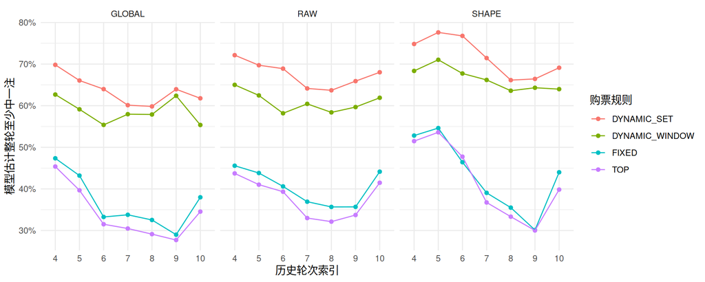

```r
rounds |> ggplot(aes(factor(index),model_any_hit,colour=policy,group=policy))+
 geom_point()+geom_line()+facet_wrap(~model)+scale_y_continuous(labels=scales::percent)+
 labs(x='历史轮次索引',y='模型估计整轮至少中一注',colour='购票规则')+theme_minimal()
```

## 每组的区间是否真的不同

DYNAMIC_SET的min/max只是所购注的排名跨度，不能解释成连续区间。下表给出全部动态连续窗口，便于核实是否存在“每组不同”的实际行为。

```r
knitr::kable(windows |> filter(policy=='DYNAMIC_WINDOW') |>
 select(index,model,step,group_id,min_rank,max_rank,marginal_coverage),digits=5)
```

| index | model | step | group_id | min_rank | max_rank | marginal_coverage |
| --- | --- | --- | --- | --- | --- | --- |
| 4 | RAW | 1 | g04 | 1 | 125 | 0.24658 |
| 4 | RAW | 2 | g05 | 133 | 257 | 0.10947 |
| 4 | RAW | 3 | g07 | 115 | 239 | 0.06796 |
| 4 | RAW | 4 | g02 | 352 | 476 | 0.06250 |
| 4 | RAW | 5 | g01 | 665 | 789 | 0.05386 |
| 4 | RAW | 6 | g08 | 825 | 949 | 0.04029 |
| 4 | RAW | 7 | g03 | 122 | 246 | 0.03627 |
| 4 | RAW | 8 | g06 | 827 | 951 | 0.03314 |
| 4 | GLOBAL | 1 | g04 | 1 | 125 | 0.22991 |
| 4 | GLOBAL | 2 | g05 | 136 | 260 | 0.09855 |
| 4 | GLOBAL | 3 | g06 | 293 | 417 | 0.07447 |
| 4 | GLOBAL | 4 | g07 | 265 | 389 | 0.06122 |
| 4 | GLOBAL | 5 | g01 | 497 | 621 | 0.05003 |
| 4 | GLOBAL | 6 | g08 | 370 | 494 | 0.04378 |
| 4 | GLOBAL | 7 | g02 | 655 | 779 | 0.03676 |
| 4 | GLOBAL | 8 | g03 | 823 | 947 | 0.03208 |
| 4 | SHAPE | 1 | g04 | 1 | 125 | 0.29444 |
| 4 | SHAPE | 2 | g06 | 134 | 258 | 0.09832 |
| 4 | SHAPE | 3 | g05 | 241 | 365 | 0.07929 |
| 4 | SHAPE | 4 | g07 | 251 | 375 | 0.05783 |
| 4 | SHAPE | 5 | g02 | 451 | 575 | 0.05291 |
| 4 | SHAPE | 6 | g01 | 762 | 886 | 0.03720 |
| 4 | SHAPE | 7 | g08 | 220 | 344 | 0.03549 |
| 4 | SHAPE | 8 | g03 | 92 | 216 | 0.02810 |
| 5 | RAW | 1 | g03 | 1 | 125 | 0.22985 |
| 5 | RAW | 2 | g01 | 134 | 258 | 0.09977 |
| 5 | RAW | 3 | g08 | 259 | 383 | 0.07045 |
| 5 | RAW | 4 | g02 | 470 | 594 | 0.06253 |
| 5 | RAW | 5 | g06 | 327 | 451 | 0.05190 |
| 5 | RAW | 6 | g05 | 839 | 963 | 0.04030 |

[output cut: 138 more lines]

```r
knitr::kable(windows |> group_by(model,policy) |> summarise(groups=n(),
 begins_after_first=sum(min_rank>1),minimum_rank=min(min_rank),maximum_rank=max(max_rank),.groups='drop'))
```

| model | policy | groups | begins_after_first | minimum_rank | maximum_rank |
| --- | --- | --- | --- | --- | --- |
| GLOBAL | DYNAMIC_SET | 56 | 47 | 1 | 1614 |
| GLOBAL | DYNAMIC_WINDOW | 56 | 48 | 1 | 1372 |
| GLOBAL | FIXED | 56 | 56 | 30 | 154 |
| GLOBAL | TOP | 56 | 0 | 1 | 125 |
| RAW | DYNAMIC_SET | 56 | 49 | 1 | 1487 |
| RAW | DYNAMIC_WINDOW | 56 | 49 | 1 | 1250 |
| RAW | FIXED | 56 | 56 | 30 | 154 |
| RAW | TOP | 56 | 0 | 1 | 125 |
| SHAPE | DYNAMIC_SET | 56 | 49 | 1 | 1485 |
| SHAPE | DYNAMIC_WINDOW | 56 | 49 | 1 | 1432 |
| SHAPE | FIXED | 56 | 56 | 30 | 154 |
| SHAPE | TOP | 56 | 0 | 1 | 125 |

## 回款与成本

只在12方案共同现金完整的轮次进行同预算现金比较；官方结算SP缺失的中奖票仍列命中，但回款不估算。结算只使用一次0.65票级系数。

```r
common <- rounds |> group_by(index) |> summarise(ok=all(monetary_complete),.groups='drop') |> filter(ok)
cash <- rounds |> semi_join(common,by='index') |> group_by(model,policy) |>
 summarise(rounds=n(),cost_cny=sum(cost_cny),payout_cny=sum(payout_cny),net_cny=sum(net_cny),.groups='drop')
knitr::kable(cash,digits=2)
```

| model | policy | rounds | cost_cny | payout_cny | net_cny |
| --- | --- | --- | --- | --- | --- |
| GLOBAL | DYNAMIC_SET | 3 | 6000 | 7314.23 | 1314.23 |
| GLOBAL | DYNAMIC_WINDOW | 3 | 6000 | 1400.90 | -4599.10 |
| GLOBAL | FIXED | 3 | 6000 | 1424.26 | -4575.74 |
| GLOBAL | TOP | 3 | 6000 | 895.16 | -5104.84 |
| RAW | DYNAMIC_SET | 3 | 6000 | 4514.84 | -1485.16 |
| RAW | DYNAMIC_WINDOW | 3 | 6000 | 8931.57 | 2931.57 |
| RAW | FIXED | 3 | 6000 | 2900.52 | -3099.48 |
| RAW | TOP | 3 | 6000 | 1424.26 | -4575.74 |
| SHAPE | DYNAMIC_SET | 3 | 6000 | 1538.81 | -4461.19 |
| SHAPE | DYNAMIC_WINDOW | 3 | 6000 | 2932.79 | -3067.21 |
| SHAPE | FIXED | 3 | 6000 | 4801.09 | -1198.91 |
| SHAPE | TOP | 3 | 6000 | 3279.26 | -2720.74 |

```r
write_csv(cash,file.path(out,'cash.csv'))
```

12种方案共同现金完整的仅3轮，各自模拟投入6000元。RAW固定、TOP、动态连续、动态任意的回款约为2900.52、1424.26、8931.57、4514.84元；这是部分轮次的描述，不能推断七轮总收益或据此选择收益最优策略。其余回款继续保留NA。

## 证据、验收及复现

新增包函数FitMarginShapeCalibration、PredictMarginShapeCalibration、SelectJointOutcomeTickets及测试test-margin-shape-research.R；客户端仅组织输入与结果。模型使用stats::glm；权重/截止/分区/ESS/实现闭包来自共享temporal_learning。完整组合沿用parlay_enumerate_tickets/parlay_rank_tickets；标量联合覆盖API不能返回每个候选票的未覆盖质量，故用base rowsum对≤3^14个共享世界精确积分，不新增依赖。全部84个最终覆盖另用既有Rcpp标量内核复核。

测试以27个独立世界核验所有规则，覆盖格式、资源界限、缺失、支持不足、单类、奇异拟合、源/截止篡改和目标/未来标签变化经预测及购票不变性。旧接受快照加本次文件形成隔离测试源码，避免其他会话并行修改；只证明记录身份的交付，不声称未纳入的共享工作区改动通过。正常安装、完整R/Python套件、DLL实际调用、无缓存渲染及最终codex review均须在验收JSON中有证据。

本地结果目录保留tested-package-source.tar.gz作为实际测试包的源码胶囊，不含编译产物；胶囊包含已有其他会话源码，故不纳入本次Git提交，SHA列入验收输入清单。在隔离研究目录解压并正常安装，可复现冻结版本。verification-source-manifest-final.json绑定完整测试源码身份；运行环境来自runtime-final.log，已有依赖不在函数或渲染期间安装。新实现不增加直接依赖。

首轮代码审查指出：未来期可能因错误的早期时间戳进入共享准入。已增加明确的prior_issues域提名，要求期号严格早于目标，记录排除数；回归测试将未来标签时钟改早、概率改NA，确认模型、预测和购票均不变。独立GLM环境不适合冻结比较，故仅持久化系数、诊断、共享收据；增加RDS往返及独立重拟合一致性测试。初期中止的套件/计算不作为通过证据，最终套件以full-R-tests-final.log、full-python-tests-final.log为准；各项准确命令、状态及日志路径见验收JSON。最终审查结论及源文件SHA见验收记录。

V1冻结及独立重放通过，但评分因结算列顺序不满足严格接口而停止，未形成可用对照表。V2显式排列结算列，并对实际客户端AST中的传参表达式作回归测试；原冻结包和生产它的精确源码作为证据保留。V2重新冻结并独立重放，不跨预测实现身份沿用V1缓存。评分随后拆为独立客户端；producer-source.R保存已重放的确切生产源码，评分明确核验此不可变输入证据及自身实现SHA，不将新评分代码冒充预测生产代码。当前生产客户端移除了失效的评分分支，新增AST回归验证其决策计算循环与冻结版本完全一致。概率、选票算法和参数没有因该接口修复而调整。实际运行包及源码胶囊位于原results/margin-combination-study-20261018目录，V2结果位于同名加-v2目录，均由验收SHA绑定。

```r
receipts <- map_dfr(x$rounds,~map_dfr(names(.x$fits),function(model) {
 f <- .x$fits[[model]]
 tibble(index=.x$index,model,cutoff=format(.x$cutoff$cutoff_utc,tz='UTC',usetz=TRUE),
  training_n=nrow(f$admitted),maximum_source=f$receipt$maximum_source_time,
  maximum_label=f$receipt$maximum_training_label_timestamp,cache_key=f$receipt$cache_key)
}))
knitr::kable(receipts)
```

| index | model | cutoff | training_n | maximum_source | maximum_label | cache_key |
| --- | --- | --- | --- | --- | --- | --- |
| 4 | GLOBAL | 2026-10-14 14:25:51 UTC | 322 | 2026-10-09T15:03:08.709484+00:00 | 2026-10-09T15:03:08.709484+00:00 | 9aa92bf8ab2bda050e321865aa374c6e80fbbb4cfbe4d6e7a8b15da759870741 |
| 4 | SHAPE | 2026-10-14 14:25:51 UTC | 322 | 2026-10-09T15:03:08.709484+00:00 | 2026-10-09T15:03:08.709484+00:00 | 918920c0dfeb68a52b36547adf757d2f7150bd35c257c7e23bda78c378b0d2ef |
| 5 | GLOBAL | 2026-10-14 14:25:51 UTC | 322 | 2026-10-09T15:03:08.709484+00:00 | 2026-10-09T15:03:08.709484+00:00 | 9aa92bf8ab2bda050e321865aa374c6e80fbbb4cfbe4d6e7a8b15da759870741 |
| 5 | SHAPE | 2026-10-14 14:25:51 UTC | 322 | 2026-10-09T15:03:08.709484+00:00 | 2026-10-09T15:03:08.709484+00:00 | 918920c0dfeb68a52b36547adf757d2f7150bd35c257c7e23bda78c378b0d2ef |
| 6 | GLOBAL | 2026-10-15 16:41:39 UTC | 322 | 2026-10-09T15:03:08.709484+00:00 | 2026-10-09T15:03:08.709484+00:00 | 20db0a8b16512bc56c92a86fd406942c22cb8ca8ba5225c1802b21b23825c865 |
| 6 | SHAPE | 2026-10-15 16:41:39 UTC | 322 | 2026-10-09T15:03:08.709484+00:00 | 2026-10-09T15:03:08.709484+00:00 | 62d69d19e0607fc79f7e5e41d3021cdfd571e902772114e6bba530950c5edf34 |
| 7 | GLOBAL | 2026-10-16 15:48:46 UTC | 322 | 2026-10-09T15:03:08.709484+00:00 | 2026-10-09T15:03:08.709484+00:00 | fc086bcdaf0628cd85b61a9e822f0db9f0d968fbd3635f9a5786b5433de6798c |
| 7 | SHAPE | 2026-10-16 15:48:46 UTC | 322 | 2026-10-09T15:03:08.709484+00:00 | 2026-10-09T15:03:08.709484+00:00 | 38854f1a7fa2acee45bbca0ee91c207f229707cc7895a19d37bf29e63d823faa |
| 8 | GLOBAL | 2026-10-16 15:48:46 UTC | 322 | 2026-10-09T15:03:08.709484+00:00 | 2026-10-09T15:03:08.709484+00:00 | fc086bcdaf0628cd85b61a9e822f0db9f0d968fbd3635f9a5786b5433de6798c |
| 8 | SHAPE | 2026-10-16 15:48:46 UTC | 322 | 2026-10-09T15:03:08.709484+00:00 | 2026-10-09T15:03:08.709484+00:00 | 38854f1a7fa2acee45bbca0ee91c207f229707cc7895a19d37bf29e63d823faa |
| 9 | GLOBAL | 2026-10-16 15:48:46 UTC | 322 | 2026-10-09T15:03:08.709484+00:00 | 2026-10-09T15:03:08.709484+00:00 | fc086bcdaf0628cd85b61a9e822f0db9f0d968fbd3635f9a5786b5433de6798c |
| 9 | SHAPE | 2026-10-16 15:48:46 UTC | 322 | 2026-10-09T15:03:08.709484+00:00 | 2026-10-09T15:03:08.709484+00:00 | 38854f1a7fa2acee45bbca0ee91c207f229707cc7895a19d37bf29e63d823faa |
| 10 | GLOBAL | 2026-10-16 15:48:46 UTC | 322 | 2026-10-09T15:03:08.709484+00:00 | 2026-10-09T15:03:08.709484+00:00 | fc086bcdaf0628cd85b61a9e822f0db9f0d968fbd3635f9a5786b5433de6798c |
| 10 | SHAPE | 2026-10-16 15:48:46 UTC | 322 | 2026-10-09T15:03:08.709484+00:00 | 2026-10-09T15:03:08.709484+00:00 | 38854f1a7fa2acee45bbca0ee91c207f229707cc7895a19d37bf29e63d823faa |

```r
if(isTRUE(params$require_acceptance)) {
 acceptance <- jsonlite::fromJSON(file.path(out,'acceptance.json'))
 stopifnot(acceptance$status=='ACCEPTED',all(acceptance$checks$exit_status==0L),
  all(acceptance$tests$failed==0),all(acceptance$tests$errors==0),all(acceptance$tests$skipped==0))
 for(path in names(acceptance$source_hashes))stopifnot(digest::digest(
   file=file.path(root,path),algo='sha256')==acceptance$source_hashes[[path]])
}
if(isTRUE(params$require_acceptance))knitr::kable(acceptance$checks)
```

[output not shown]

```r
if(isTRUE(params$require_acceptance))knitr::kable(acceptance$tests)
```

| suite | tests | passed | failed | errors | warnings | skipped |
| --- | --- | --- | --- | --- | --- | --- |
| package | 991 | 9647 | 0 | 0 | 0 | 0 |
| repository | 802 | 183264 | 0 | 0 | 0 | 0 |
| Python backend | 643 | 643 | 0 | 0 | 0 | 0 |

```r
if(isTRUE(params$require_acceptance))knitr::asis_output(paste0('审查结论：',acceptance$review$verdict,'。审查命令、日志和所审查源文件SHA记录如下；最终工件复核另见final-review-receipt.json。'))
```

审查结论：No blocking findings; full source/data/test review plus QMD evidence-table display correction reviewed.。审查命令、日志和所审查源文件SHA记录如下；最终工件复核另见final-review-receipt.json。

```r
if(isTRUE(params$require_acceptance))knitr::kable(tibble(path=names(acceptance$source_hashes),sha256=unlist(acceptance$source_hashes)))
```

| path | sha256 |
| --- | --- |
| packages/beidan/R/margin_shape_research.R | 1105d86efc421f41cf95cfa879a91d41459981305cf7a66aa95c9f1e4d413324 |
| packages/beidan/tests/testthat/test-margin-shape-research.R | e7ce52a6c8504d76352015852cf88049f0eb5d75f6e8c013ae6984612720c841 |
| r/margin_combination_study_20261018.R | 9385113e68397f43318ac98e1446e9ef00b50bce4a03fbf3c84d0bf7644e047d |
| r/evaluate_margin_combination_20261018.R | 44ad8f428d7a4c0c788efd6ae4981cf938ed23b13101c899c69a15c990dea929 |
| tests/testthat/test-margin-combination-study.R | a2b13ed1cde48d165e17fd3d89d29c85da5a6b1e8c79fae947c137f6f2888975 |
| quarto/margin_combination_study_20261018.qmd | 7341f700a679399dc4986aa5dab2cc10d4cfe3c98bb27b3b8647cd895acd53ea |
| config/fundamental-models/FM-1.7.1.json | f63e06561034b95f96e57d2983db29fd73af5f876f0e687e3a1f4e54cec265d2 |
| results/margin-combination-study-20261018-v2/producer-source.R | ae3274d4888d944a542032ddeadd25639808492ea9a449424ced5404c124431f |
| results/margin-combination-study-20261018/tested-package-source.tar.gz | 6f97f8bdba47c988f32cef47c03282ef85000a258991ed21da65803f5c137cb2 |
| results/margin-combination-study-20261018-v2/cutoff-audit-command.R | 6fabc1a79bc054a86075ceabe61b949f58515bb7a37dfb246e2e79a441621101 |
| results/margin-combination-study-20261018-v2/runtime-command.R | 5e1003a2dcf84962ad2b3f35b1f99cc5f60e0c4eb4fd90c284e2e793cdf137d8 |
| results/margin-combination-study-20261018-v2/html-validation-command.py | db903ccca0329af8d89d0e73ff5160e5f34254feb1f238946c761c2a93649278 |

```r
if(!isTRUE(params$require_acceptance))knitr::asis_output('**阶段报告：完整验收尚未完成，不能将当前渲染视为最终交付。**')
```

复现：在隔离目录解压源码胶囊，提供manifest列出的冻结输入及本次客户端；设置config/source-extraction.env与显式项目Python/R库，正常安装到results/margin-combination-study-20261018/library；依次运行 `Rscript r/margin_combination_study_20261018.R ROOT freeze`、同命令`replay`；评分使用独立的`Rscript r/evaluate_margin_combination_20261018.R ROOT`。 freeze拒绝覆盖已有冻结包；独立重放不会改写模型。运行 `quarto render quarto/margin_combination_study_20261018.qmd --no-cache -P project_root:ROOT`。 原始输入与各层输出SHA在manifest/evaluation中；代码与环境身份及完整检查命令见验收记录。正式FM版本与已冻结模拟单不变。本轮只能提出待验证候选；任何据此挑选的规则需再冻结并等待新期验证。

复现本次既有V2预测时，先在隔离研究根目录将producer-source.R还原到manifest所记的r/margin_combination_study_20261018.R路径，再运行该冻结版本的replay模式；不要覆盖正在使用的源码。当前生产客户端的freeze用于新的空输出目录上下文，拒绝重写已有冻结包。评分不执行或导入归档生产源码，只核验其字节SHA。

报告渲染只读取已独立重算、按源数据/实现身份及SHA验收的派生表；所有汇总和图在干净R会话重新执行。knitr缓存和freeze关闭。完整评分独立重放的结果见evaluation-replay.json；复现先运行独立评分客户端，再渲染报告，无需因展示修改重复拟合或选票。